# DNA methylation desing to discovery 2026

Dr. Gilles Gasparoni, Lukas Laufer, Nihit Aggarwal

## Day 1

### Setting up the environment

#### Installing packages

In this section, we will install RnBeads package from Bioconductor, essential for analyzing Infinium methylation arrays.

```r
# installing RnBeads
if (!requireNamespace("BiocManager", quietly = TRUE))
    install.packages("BiocManager")
BiocManager::install("FDb.InfiniumMethylation.hg19")

source("http://rnbeads.org/data/install.R")
```

#### Loading packages

we specify a list of essential R packages, including ggplot2, reshape2, RnBeads, and data.table, which are fundamental for data visualization and analysis in epigenetics studies. The lapply function is then used to load each package in the list, ensuring they are available for use in subsequent analyses.

```r
packages_to_load <- c("ggplot2","reshape2","RnBeads","data.table","pheatmap","RColorBrewer","GOstats")
lapply(packages_to_load, require, character.only=TRUE)
```

```
[[1]]
[1] TRUE

[[2]]
[1] TRUE

[[3]]
[1] TRUE

[[4]]
[1] TRUE

[[5]]
[1] TRUE

[[6]]
[1] TRUE

[[7]]
[1] TRUE
```

### Primary analysis

#### Data and samplesheet preparation

In this segment, we are setting up the file paths and directories necessary for handling DNA methylation data in our epigenetics workshop. The code defines the locations for the raw data (`idat.dir`), the output directory (`report.dir`), and the sample sheet (`sample.annotation`), preparing us to import and analyze the data effectively in subsequent steps.

```r
# preparing sample sheet and data import for selected samples

# set the working directory
setwd("D:/Work/Epigenetics/Workshops/2024_deNBI-DNA_methylation_design_to_discovery/")

# path to data.files
idat.dir <- file.path("idat/")

# outputPath
report.dir <- "analysis_v5/"

# samplesheet file path
sample.annotation <- file.path("20241202_SampleSheet_SelectedSamples.txt")

data.type<-"idat.dir"
```

We first use the `help("rnb.options")` function to display detailed information about configurable parameters available in the RnBeads package. Following this, we configure several RnBeads options, setting the genome assembly to “hg19,” specifying the identifiers column as “SampleID,” and defining the import table separator as a tab. Finally, we export these configurations to an XML format with improved readability using `rnb.options2xml(pretty=TRUE)`. This setup ensures our RnBeads analyses are tailored to our specific dataset and preferences.

```r
# get info on all available RnB parameters.
help("rnb.options")

# setting rnbeads options
rnb.options(assembly = "hg19")
rnb.options(identifiers.column = "SampleID")
rnb.options(import.table.separator = "\t")
rnb.options2xml(pretty=TRUE)
```

```
[1] "<rnb.xml>\n\t<analysis.name null=\"null\"></analysis.name>\n\t<logging>true</logging>\n\t<email null=\"null\"></email>\n\t<assembly>hg19</assembly>\n\t<columns.pairing null=\"null\"></columns.pairing>\n\t<analyze.sites>true</analyze.sites>\n\t<region.types null=\"null\"></region.types>\n\t<regi…
```

#### RnBeads set

The code initializes the RnBeads analysis by importing DNA methylation data and associated sample annotations from specified directories, subsequently storing the resulting RnBeads dataset object for further analysis.

```r
# import rnbead set
rnbSet = rnb.run.import(data.source = c(idat.dir, sample.annotation),
                        data.type = data.type,
                        dir.reports = report.dir)
```

```
2026-01-14 17:25:36     Inf  STATUS         STARTED Loading Data
```

```
2026-01-14 17:25:36     Inf    INFO             Number of cores: 1
```

```
2026-01-14 17:25:36     Inf    INFO             Loading data of type "idat.dir"
```

```
2026-01-14 17:25:36     Inf  STATUS             STARTED Loading Data from IDAT Files
```

```
2026-01-14 17:25:36     Inf    INFO                 Added column barcode to the provided sample annotation table
```

```
2026-01-14 17:25:36     Inf    INFO                 Detected platform: HumanMethylation450
```

```
2026-01-14 17:26:20     Inf  STATUS             COMPLETED Loading Data from IDAT Files
```

```
2026-01-14 17:29:30     Inf  STATUS             Loaded data from idat
```

```
2026-01-14 17:29:33     Inf  STATUS             Predicted sex for the loaded samples
```

```
2026-01-14 17:29:35     Inf  STATUS             Added data loading section to the report
```

```
2026-01-14 17:29:35     Inf  STATUS             Loaded 64 samples and 485577 sites
```

```
2026-01-14 17:29:35     Inf    INFO             Output object is of type RnBeadRawSet
```

```
2026-01-14 17:29:35     Inf  STATUS         COMPLETED Loading Data
```

```r
rnb = rnbSet$rnb.set
```

#### Features of RnBeads object

```r
# Let's inspect some features of our dataset

# View Sample Sheet
head(pheno(rnb))
```

|  | GEO_ID | SampleID | DonorID | Sex | Age | Type | CellType | Tissue | Diagnosis | Group | stage | Sentrix_ID | Sentrix_Position | Sentrix_Adress | AD_vs_CTRL_Neuron | AD_vs_CTRL_Glia | AD_vs_CTRL_FC | AD_vs_CTRL_TC | barcode | Predicted Male Probability | Predicted Sex |
| --- | --- | --- | --- | --- | --- | --- | --- | --- | --- | --- | --- | --- | --- | --- | --- | --- | --- | --- | --- | --- | --- |
| 1 | GSM2808875 | Dnr01_F_78_AD_Glia | Dnr01 | F | 78 | Sorted | Glia | NA | AD | Glia_AD | 6 | 8918692108 | R01C02 | 8918692108_R01C02 | NA | Glia_AD | NA | NA | 8918692108_R01C02 | 0.0037398910 | female |
| 2 | GSM2808876 | Dnr01_F_78_AD_Neuron | Dnr01 | F | 78 | Sorted | Neuron | NA | AD | Neuron_AD | 6 | 8918692108 | R01C01 | 8918692108_R01C01 | Neuron_AD | NA | NA | NA | 8918692108_R01C01 | 0.0023470226 | female |
| 3 | GSM2808877 | Dnr02_M_76_AD_Glia | Dnr02 | M | 76 | Sorted | Glia | NA | AD | Glia_AD | 6 | 8918692108 | R02C02 | 8918692108_R02C02 | NA | Glia_AD | NA | NA | 8918692108_R02C02 | 0.9984741689 | male |
| 4 | GSM2808878 | Dnr02_M_76_AD_Neuron | Dnr02 | M | 76 | Sorted | Neuron | NA | AD | Neuron_AD | 6 | 8918692108 | R02C01 | 8918692108_R02C01 | Neuron_AD | NA | NA | NA | 8918692108_R02C01 | 0.9983924299 | male |
| 5 | GSM2808893 | Dnr13_F_77_CTRL_Glia | Dnr13 | F | 77 | Sorted | Glia | NA | CTRL | Glia_CTRL | 0 | 8221932039 | R04C01 | 8221932039_R04C01 | NA | Glia_CTRL | NA | NA | 8221932039_R04C01 | 0.0001634888 | female |
| 6 | GSM2808894 | Dnr13_F_77_CTRL_Neuron | Dnr13 | F | 77 | Sorted | Neuron | NA | CTRL | Neuron_CTRL | 0 | 8221932039 | R03C01 | 8221932039_R03C01 | Neuron_CTRL | NA | NA | NA | 8221932039_R03C01 | 0.0000999754 | female |

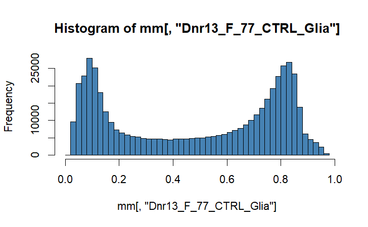

```r
# Retrieve Raw Methylation Values
mm <- meth(rnb)

# Plot Raw Methylation Values Histogram
hist(mm[,"Dnr13_F_77_CTRL_Glia"], col="steelblue", breaks=50)
```

```r
# Check if Regions are Summarized and How
summarized.regions(rnb)
```

```
[1] "tiling"     "genes"      "promoters"  "cpgislands"
```

##### Working with Annotations

```r
# Inspect Available Annotation for Probes
anno = rnb.annotation2data.frame(rnb.get.annotation("probes450"))
head(anno)
```

|  | Chromosome | Start | End | Strand | Strand.1 | AddressA | AddressB | Design | Color | Context | Random | HumanMethylation27 | Mismatches A | Mismatches B | CGI Relation | CpG | GC | SNPs 3 | SNPs 5 | SNPs Full | Cross-reactive | ID |
| --- | --- | --- | --- | --- | --- | --- | --- | --- | --- | --- | --- | --- | --- | --- | --- | --- | --- | --- | --- | --- | --- | --- |
| cg13869341 | chr1 | 15865 | 15866 | + | + | 62703328 | 16661461 | I | Red | CG | FALSE | FALSE | 0 | 0 | Open Sea | 5 | 63 | 0 | 0 | 1 | 0 | cg13869341 |
| cg14008030 | chr1 | 18827 | 18828 | + | + | 27651330 | 27651330 | II | Both | CG | FALSE | FALSE | 0 | 0 | Open Sea | 4 | 57 | 0 | 0 | 1 | 8 | cg14008030 |
| cg12045430 | chr1 | 29407 | 29408 | + | + | 25703424 | 34666387 | I | Red | CG | FALSE | FALSE | 0 | 1 | Island | 15 | 81 | 0 | 0 | 0 | 4 | cg12045430 |
| cg20826792 | chr1 | 29425 | 29426 | + | + | 61731400 | 14693326 | I | Red | CG | FALSE | FALSE | 0 | 0 | Island | 14 | 80 | 0 | 0 | 0 | 4 | cg20826792 |
| cg00381604 | chr1 | 29435 | 29436 | + | + | 26752380 | 50693408 | I | Red | CG | FALSE | FALSE | 0 | 1 | Island | 17 | 82 | 0 | 0 | 0 | 3 | cg00381604 |
| cg20253340 | chr1 | 68849 | 68850 | + | + | 49752305 | 49752305 | II | Both | CG | FALSE | FALSE | 0 | 0 | Open Sea | 2 | 36 | 0 | 0 | 0 | 2 | cg20253340 |

```r
# View Annotation Available for Promoters
annot.promoters <- annotation(rnb, type="promoters")
head(annot.promoters)
```

|  | Chromosome | Start | End | Strand | symbol | entrezID | CpG | GC | C | G |
| --- | --- | --- | --- | --- | --- | --- | --- | --- | --- | --- |
| ENSG00000227232 | chr1 | 29307 | 31306 | - | WASH7P | 653635;100287171 | 78 | 1047 | 580 | 467 |
| ENSG00000243485 | chr1 | 28054 | 30053 | + | MIR1302-10;MIR1302-11;MIR1302-2;MIR1302-9 | 100302278;100422831;100422834;100422919 | 131 | 1158 | 644 | 514 |
| ENSG00000186092 | chr1 | 67591 | 69590 | + | OR4F5 | 79501 | 15 | 729 | 421 | 308 |
| ENSG00000239945 | chr1 | 90606 | 92605 | - | NA | NA | 29 | 944 | 456 | 488 |
| ENSG00000239664 | chr1 | 532379 | 534378 | - | NA | NA | 126 | 1090 | 597 | 493 |
| ENSG00000223659 | chr1 | 563891 | 565890 | - | NA | 101928626 | 38 | 837 | 578 | 259 |

##### Detailed Methylation Analysis

```r
# get methylation for promoters (on a subset of samples and promoters just for illustration)
meth(rnb, type="promoters", row.names=TRUE, i=1:5, j=1:3)
```

```
                Dnr01_F_78_AD_Glia Dnr01_F_78_AD_Neuron Dnr02_M_76_AD_Glia
ENSG00000227232          0.1403972            0.1315872          0.1278670
ENSG00000243485          0.1403972            0.1315872          0.1278670
ENSG00000186092          0.4823335            0.4926567          0.6153535
ENSG00000239945          0.1836442            0.2376329          0.2308111
ENSG00000239664          0.8244361            0.8375767          0.8213666
```

```r
# inspect coverage (number of beads per probe)
nbead <- covg(rnb, row.names=TRUE)
nbead[1:5,1:3]
```

```
           Dnr01_F_78_AD_Glia Dnr01_F_78_AD_Neuron Dnr02_M_76_AD_Glia
cg13869341                 10                   15                 15
cg14008030                 11                   14                 14
cg12045430                 13                    9                 16
cg20826792                 12                   12                  7
cg00381604                 15                   10                 10
```

```r
# detection p-values
pvals <- dpval(rnb, row.names=TRUE)
```

##### Diagnostic Plots

```r
# check control probes
rnb.plot.control.boxplot(rnb)
```

```r
# some specific control
rnb.plot.control.boxplot(rnb, "BISULFITE CONVERSION I")

# Negative control boxplots are generated with the following command:
rnb.plot.negative.boxplot(rnb)

# barplot of a selected control probe
control.meta.data <- rnb.get.annotation("controls450")
ctrl.probe<-paste0(unique(control.meta.data[["Target"]])[2], ".1")
rnb.plot.control.barplot(rnb, ctrl.probe)

# access to full qc results
qc_data = qc(rnb)
```

##### Genotyping and Additional Analysis

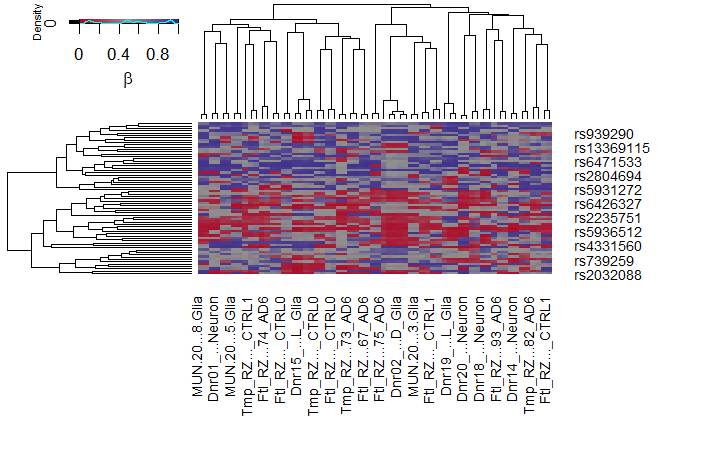

```r
#use some genotyping probes to check for genomic sample similarity
snp.probes = anno[grep("rs", rownames(anno)), ]

rnb.plot.snp.heatmap(rnb)
```

```r
#rnb.plot.snp.barplot(dataset = rnb, probeID = rownames(snp.probes) [2], writeToFile = TRUE)

#set some options as desired before running the complete quality check module
rnb.options(qc.snp.boxplot=TRUE)
rnb.options(import.sex.prediction = TRUE)
rnb.options(qc.cnv = TRUE) # calculate copy number variations
```

#### Quality check

```r
#see all available options
help("rnb.options") #get info on all available RnB parameters.

#run complete quality report with specific settings

#QC
rnb.options(qc.boxplots = TRUE)
rnb.options(qc.barplots = TRUE)
rnb.options(qc.negative.boxplot = TRUE)
rnb.options(qc.snp.distances = TRUE)
rnb.options(qc.snp.boxplot = TRUE)
rnb.options(qc.snp.barplot = TRUE)
rnb.options(qc.sample.batch.size = 50)
rnb.options(qc.coverage.plots = FALSE)
rnb.options(qc.coverage.threshold.plot = 1:10)
rnb.options(qc.coverage.histograms = FALSE)
rnb.options(qc.coverage.violins = FALSE)

rnb.run.qc(rnb.set = rnb, dir.reports = report.dir) #this will takes some minutes
```

```
2026-01-14 17:31:37     Inf  STATUS         STARTED Quality Control
```

```
2026-01-14 17:31:37     Inf    INFO             Number of cores: 1
```

```
2026-01-14 17:31:37     Inf  STATUS             STARTED Quality Control Section
2026-01-14 17:31:55     Inf  STATUS                 Added quality control box plots
2026-01-14 17:35:09     Inf  STATUS                 Added quality control bar plots
2026-01-14 17:35:14     Inf  STATUS                 Added negative control boxplots
2026-01-14 17:35:14     Inf  STATUS             COMPLETED Quality Control Section
2026-01-14 17:35:14     Inf  STATUS             STARTED Visualizing SNP Probe Data
2026-01-14 17:35:14     Inf  STATUS                 STARTED Mixups Visualization Section
2026-01-14 17:35:21     Inf  STATUS                     Added SNP Heatmap
2026-01-14 17:37:27     Inf  STATUS                     Added SNP Bar Plots
2026-01-14 17:37:30     Inf  STATUS                     Added SNP Box Plot
2026-01-14 17:37:30     Inf  STATUS                     Calculated Manhattan distances between samples based on SNP probes
2026-01-14 17:37:31     Inf  STATUS                     Added SNP-based Distances
2026-01-14 17:37:31     Inf  STATUS                 COMPLETED Mixups Visualization Section
2026-01-14 17:37:31     Inf  STATUS             COMPLETED Visualizing SNP Probe Data
2026-01-14 17:37:39     Inf WARNING             CNV calling currently not supported due to dependency issues
2026-01-14 17:37:39     Inf  STATUS             STARTED Copy Number Variation
2026-01-14 17:37:39     Inf WARNING                 CNV calling currently not supported due to dependency issues
2026-01-14 17:37:39     Inf  STATUS             COMPLETED Copy Number Variation
2026-01-14 17:37:39     Inf  STATUS         COMPLETED Quality Control
```

### Preprocessing

The following R code outlines the preprocessing steps for DNA methylation data using the RnBeads package. It begins by backing up the original unprocessed dataset. Various filtering techniques are then applied to remove undesirable data points based on criteria such as CpG context, SNP presence, and data quality (e.g., missing or low-variability values). Each filtering step concludes with a check on the remaining data, ensuring the refined dataset is ready for further analysis.

#### Filtering

```r
# preprocessing typically includes filtering of undesired datapoints (mostly sites) and data normalization
rnb.unprocessed = rnb #first we store the unprocessed rnbeads object as a back-up
#save.rnb.set(rnb.unprocessed, "/projects/researchers/jil/projects/deNBI/20241129_WS24/analysis/rnb/rnbSet_Unprocessed", archive = TRUE)

nrow(meth(rnb.unprocessed)) # the number of sites in the unfiltered object
```

```
[1] 485577
```

```r
#some examples of how sites to be removed from dataset
# Remove probes outside of CpG context
rnb.set.filtered <- rnb.execute.context.removal(rnb.set = rnb.unprocessed, contexts = NULL )$dataset
nrow(meth(rnb.set.filtered)) # the number of CpG sites in the unfiltered object
```

```
[1] 485577
```

```r
# SNP filtering allowing no SNPs in the probe sequence (range 3 bp)
rnb.set.filtered <- rnb.execute.snp.removal(rnb.set = rnb.set.filtered, snp = "3")$dataset

# Removal of CpG sites in the unfiltered object
# that contain a SNP in the range of 3bp
nrow(meth(rnb.set.filtered))
```

```
[1] 475446
```

```r
# Remove CpGs on sex chromosomes
rnb.set.filtered <- rnb.execute.sex.removal(rnb.set = rnb.set.filtered)$dataset
nrow(meth(rnb.set.filtered))
```

```
[1] 463881
```

```r
# Remove probes and samples based on a greedycut approach
greedycut.results <- rnb.execute.greedycut(rnb.set = rnb.set.filtered, pval.threshold = 0.05)#$dataset
```

```
2026-01-14 17:46:49     Inf    INFO         Working with a p-value threshold of 0.05
```

```
2026-01-14 17:46:59     Inf  STATUS         Calculated a total of 2042 iterations
```

```
2026-01-14 17:46:59     Inf    INFO         Optimal number of iterations is 2042
```

```r
to_remove = rownames(meth(object = rnb.set.filtered, row.names = TRUE)) [greedycut.results[["sites"]]]
remove.sites(object = rnb.set.filtered, probelist = to_remove)
```

```
Object of class RnBeadRawSet
      64 samples
  461840 probes
    of which: 458833 CpG, 2950 CpH, and 57 rs
Region types:
      133353 regions of type tiling
       29825 regions of type genes
       29991 regions of type promoters
       25829 regions of type cpgislands
Intensity information is present
Detection p-values are present
Bead counts are present
Quality control information is present
Summary of normalization procedures:
    The methylation data was not normalized.
    No background correction was performed.
```

```r
nrow(meth(rnb.set.filtered))
```

```
[1] 463881
```

```r
# Remove probes containing NA for beta values
rnb.set.filtered <- rnb.execute.na.removal(rnb.set.filtered)$dataset
nrow(meth(rnb.set.filtered))
```

```
[1] 463881
```

```r
# Remove probes for which the beta values have low standard deviation
rnb.set.filtered <- rnb.execute.variability.removal(rnb.set.filtered, 0.005)$dataset
nrow(meth(rnb.set.filtered))
```

```
[1] 463864
```

```r
# we remove sites with any NA or negative values
mm = meth(rnb.set.filtered, row.names = TRUE)
mneg = apply(mm, 1, function(x) any(x <= 0))
mneg = is.na(mneg)
head(mm[mneg, 1:3],10)
```

```
           Dnr01_F_78_AD_Glia Dnr01_F_78_AD_Neuron Dnr02_M_76_AD_Glia
cg24598973          0.6037227           0.35977533         0.68252336
cg15988843                 NA           0.11211118         0.12834385
cg11103442                 NA           0.08739884         0.14370488
cg15703790                 NA           0.87636323         0.88330614
cg14171824                 NA           0.06192138         0.14825345
cg05706173          0.8849225           0.86287861         0.89148936
cg20664247          0.6185289           0.38474008         0.60286445
cg14655532          0.8582199           0.72876654         0.87436677
cg17826013          0.0324402                   NA         0.03648129
cg10982045          0.5719655           0.66639436         0.57617421
```

```r
rnb.set.filtered = remove.sites(object = rnb.set.filtered, probelist = mneg)
nrow(meth(rnb.set.filtered))
```

```
[1] 462983
```

```r
#save.rnb.set(rnb.set.filtered, "/projects/researchers/jil/projects/deNBI/20241129_WS24/analysis/rnb/rnbSet_Filtered", archive = TRUE)
```

#### Normalization

We now configure a series of RnBeads package options for filtering and normalization of DNA methylation data. It specifies parameters such as SNP filtering, cross-reactivity exclusion, and the handling of missing values and coverage thresholds. Additionally, it sets up normalization methods, including background correction and method adjustment. The final command executes the predefined preprocessing steps on the filtered dataset and stores the processed data in the `rnb` object for further analysis.

```r
#preset some options and then run filtering/normalization with one command
# Set filtering and normalization options using a consolidated approach
rnb.options(filtering.whitelist = NULL)
rnb.options(filtering.blacklist = NULL)
rnb.options(filtering.snp = "3")
rnb.options(filtering.cross.reactive = FALSE)
rnb.options(filtering.greedycut = TRUE)
rnb.options(filtering.greedycut.pvalue.threshold = 0.05)
rnb.options(filtering.greedycut.rc.ties = "row")
rnb.options(filtering.sex.chromosomes.removal = TRUE)
rnb.options(filtering.missing.value.quantile = 0.8)
rnb.options(filtering.coverage.threshold = 3)
rnb.options(filtering.low.coverage.masking = FALSE)
rnb.options(filtering.high.coverage.outliers = FALSE)
rnb.options(filtering.deviation.threshold = 0)

rnb.options(normalization = NULL)
rnb.options(normalization.method = "bmiq")       #normalization method
rnb.options(normalization.background.method = "methylumi.noob")#background removal yes/no
rnb.options(normalization.plot.shifts = TRUE)



#rnb.set.norm <- rnb.execute.normalization(rnb.set.unfiltered, method="wm.dazen", bgcorr.method="methylumi.noob")
preprocessed = rnb.run.preprocessing(rnb.set = rnb.set.filtered, dir.reports = report.dir)
```

```
2026-01-14 18:12:03     Inf  STATUS         STARTED Preprocessing
```

```
2026-01-14 18:12:03     Inf    INFO             Number of cores: 1
```

```
2026-01-14 18:12:03     Inf  STATUS             STARTED Filtering Procedures I
```

```
2026-01-14 18:12:03     Inf  STATUS                 STARTED Removal of SNP-enriched Sites
```

```
2026-01-14 18:12:03     Inf  STATUS                     Removed 0 sites using SNP criterion "3"
```

```
2026-01-14 18:12:03     Inf  STATUS                     Added a corresponding section to the report
```

```
2026-01-14 18:12:03     Inf  STATUS                 COMPLETED Removal of SNP-enriched Sites
```

```
2026-01-14 18:12:04     Inf    INFO                 Working with a p-value threshold of 0.05
```

```
2026-01-14 18:12:04     Inf  STATUS                 STARTED Greedycut
```

```
2026-01-14 18:12:12     Inf  STATUS                     Calculated a total of 1446 iterations
```

```
2026-01-14 18:12:12     Inf    INFO                     Optimal number of iterations is 1446
2026-01-14 18:12:15     Inf  STATUS                     Created ROC plot
2026-01-14 18:12:17     Inf  STATUS                     Created line plots for matrix dimensions and other statistics
2026-01-14 18:12:17     Inf  STATUS                     Saved removed sites to D:\Work\Epigenetics\Workshops\2024_deNBI-DNA_methylation_design_to_discovery\analysis_v5\preprocessing_data/removed_sites_greedycut.csv
2026-01-14 18:12:17     Inf  STATUS                 COMPLETED Greedycut
2026-01-14 18:12:17     Inf  STATUS                 Retained 64 samples and 461538 sites
2026-01-14 18:12:17     Inf  STATUS             COMPLETED Filtering Procedures I
2026-01-14 18:12:17     Inf  STATUS             STARTED Summary of Filtering Procedures I
2026-01-14 18:12:19     Inf  STATUS                 Created summary table of removed sites, samples and unreliable measurements
2026-01-14 18:12:19     Inf  STATUS                 Added summary table of removed and retained items
2026-01-14 18:12:20     Inf    INFO                 Subsampling 462983 sites for plotting density distributions
2026-01-14 18:12:21     Inf  STATUS                 Constructed sequences of removed and retained methylation values
2026-01-14 18:12:25     Inf  STATUS                 Added comparison between removed and retained beta values
2026-01-14 18:12:25     Inf  STATUS             COMPLETED Summary of Filtering Procedures I
2026-01-14 18:12:25     Inf  STATUS             STARTED Manipulating the object
2026-01-14 18:15:19     Inf  STATUS                 Removed 1445 sites (probes)
2026-01-14 18:15:19     Inf    INFO                 Retained 461538 sites and 64 samples
2026-01-14 18:15:19     Inf  STATUS             COMPLETED Manipulating the object
2026-01-14 18:15:19     Inf  STATUS             STARTED Normalization Procedure
2026-01-14 18:20:00     Inf  STATUS                 Performed background subtraction with method methylumi.noob
2026-01-14 18:20:35     Inf  STATUS                 Normalized sample 1
2026-01-14 18:21:10     Inf  STATUS                 Normalized sample 2
2026-01-14 18:21:44     Inf  STATUS                 Normalized sample 3
2026-01-14 18:22:18     Inf  STATUS                 Normalized sample 4
2026-01-14 18:22:51     Inf  STATUS                 Normalized sample 5
2026-01-14 18:23:25     Inf  STATUS                 Normalized sample 6
2026-01-14 18:23:59     Inf  STATUS                 Normalized sample 7
2026-01-14 18:24:32     Inf  STATUS                 Normalized sample 8
2026-01-14 18:25:04     Inf  STATUS                 Normalized sample 9
2026-01-14 18:25:37     Inf  STATUS                 Normalized sample 10
2026-01-14 18:26:11     Inf  STATUS                 Normalized sample 11
2026-01-14 18:26:45     Inf  STATUS                 Normalized sample 12
2026-01-14 18:27:19     Inf  STATUS                 Normalized sample 13
2026-01-14 18:27:51     Inf  STATUS                 Normalized sample 14
2026-01-14 18:28:25     Inf  STATUS                 Normalized sample 15
2026-01-14 18:28:58     Inf  STATUS                 Normalized sample 16
2026-01-14 18:29:31     Inf  STATUS                 Normalized sample 17
2026-01-14 18:30:05     Inf  STATUS                 Normalized sample 18
2026-01-14 18:30:39     Inf  STATUS                 Normalized sample 19
2026-01-14 18:31:14     Inf  STATUS                 Normalized sample 20
```

[output cut: 66 more lines]

```
2026-01-14 19:01:26     Inf  STATUS                 Retained 64 samples and 458531 sites
2026-01-14 19:01:26     Inf  STATUS             COMPLETED Filtering Procedures II
2026-01-14 19:01:27     Inf  STATUS             STARTED Summary of Filtering Procedures II
2026-01-14 19:01:29     Inf  STATUS                 Created summary table of removed sites, samples and unreliable measurements
2026-01-14 19:01:30     Inf  STATUS                 Added summary table of removed and retained items
2026-01-14 19:01:30     Inf    INFO                 Subsampling 461538 sites for plotting density distributions
2026-01-14 19:01:31     Inf  STATUS                 Constructed sequences of removed and retained methylation values
2026-01-14 19:01:35     Inf  STATUS                 Added comparison between removed and retained beta values
2026-01-14 19:01:35     Inf  STATUS             COMPLETED Summary of Filtering Procedures II
2026-01-14 19:01:35     Inf  STATUS             STARTED Manipulating the object
2026-01-14 19:04:45     Inf  STATUS                 Removed 3007 sites (probes)
2026-01-14 19:04:45     Inf    INFO                 Retained 458531 sites and 64 samples
2026-01-14 19:04:45     Inf  STATUS             COMPLETED Manipulating the object
2026-01-14 19:04:45     Inf    INFO             Imputation was skipped, data set may still contain missing methylation values
2026-01-14 19:04:45     Inf  STATUS         COMPLETED Preprocessing
```

```r
rnb = preprocessed$rnb.set
```

#### Inference module

This block of R code performs several advanced analyses using the RnBeads package, starting with tissue deconvolution to estimate cell types via the Houseman algorithm and visualizing these estimates with a heatmap. It also evaluates immune cell content and predicts epigenetic age. The script then sets up various inference options to fine-tune the analysis parameters before running a comprehensive inference analysis. Lastly, it performs surrogate variable analysis (SVA) to adjust for potential confounders in the data, enhancing the accuracy of the results.

```r
# Tissue deconvolution - reference based celltype estimation using houseman algorithm
ct <- rnb.execute.ct.estimation(rnb, cell.type.column="CellType", test.max.markers=10000, top.markers=500)
rnb.plot.ct.heatmap(ct.obj = ct)
ct$contributions
```

```
                         Glia     Neuron
Ftl_RZ052_F82_AD5   0.7099187 0.42052342
Ftl_RZ055_M80_AD5   0.7244652 0.43086820
Ftl_RZ063_M73_AD6   0.5877664 0.59768527
Ftl_RZ065_F65_AD6   0.9050903 0.24538383
Ftl_RZ067_F67_AD6   0.7209265 0.43178780
Ftl_RZ068_F93_AD6   0.6973143 0.43113367
Ftl_RZ069_M74_AD6   0.8109431 0.32592661
Ftl_RZ070_M53_CTRL0 0.7254189 0.41816050
Ftl_RZ077_M57_CTRL1 0.8774025 0.18778171
Ftl_RZ082_F46_CTRL1 0.9230048 0.14387449
Ftl_RZ084_M50_CTRL0 0.8318920 0.29072863
Ftl_RZ085_M63_CTRL1 0.8239656 0.31139635
Ftl_RZ089_M53_CTRL0 0.8057000 0.27746612
Ftl_RZ099_F55_CTRL0 0.8249523 0.26114206
Ftl_RZ119_M75_AD6   0.8088943 0.31149248
Ftl_RZ121_M83_AD6   0.8948550 0.17529084
Ftl_RZ122_F82_AD6   0.7835898 0.34549182
Ftl_RZ145_F85_CTRL1 0.5133064 0.65680603
Ftl_RZ339_M60_CTRL0 0.8478684 0.21683224
Ftl_RZ342_F83_CTRL2 0.6974110 0.45961178
Tmp_RZ016_M83_AD6   0.7705902 0.31523839
Tmp_RZ052_F82_AD5   0.6566257 0.49171318
Tmp_RZ055_M80_AD5   0.9096774 0.18684516
Tmp_RZ063_M73_AD6   0.6957135 0.43077108
Tmp_RZ065_F65_AD6   0.8314093 0.23942099
Tmp_RZ067_F67_AD6   0.6682452 0.48064458
Tmp_RZ068_F93_AD6   0.8775926 0.22295394
Tmp_RZ069_M74_AD6   0.8521769 0.19865229
Tmp_RZ070_M53_CTRL0 0.6420405 0.50727530
Tmp_RZ077_M57_CTRL1 0.8561631 0.21770588
Tmp_RZ082_F46_CTRL1 0.8528254 0.23484437
Tmp_RZ084_M50_CTRL0 0.8332867 0.22402473
Tmp_RZ085_M63_CTRL1 0.8155648 0.28099846
Tmp_RZ089_M53_CTRL0 0.8951400 0.16996202
Tmp_RZ092_M71_CTRL1 0.8768424 0.23341724
Tmp_RZ099_F55_CTRL0 0.8326705 0.26359957
Tmp_RZ121_M83_AD6   0.7541040 0.44696917
Tmp_RZ122_F82_AD6   0.9620802 0.07590421
Tmp_RZ145_F85_CTRL1 0.6162535 0.61629975
Tmp_RZ342_F83_CTRL2 0.5541208 0.57212841
```

```r
# immune cell content
immune.content <- rnb.execute.lump(rnb)

#calculate epigenetic age
rnb.execute.age.prediction(object = rnb)
```

```
2026-01-14 19:10:14     Inf  STATUS         STARTED Performing Age Prediction
```

```
2026-01-14 19:10:15     Inf  STATUS         COMPLETED Performing Age Prediction
Object of class RnBeadRawSet
      64 samples
  458531 probes
    of which: 458531 CpG, 0 CpH, and 0 rs
Region types:
      131197 regions of type tiling
       29754 regions of type genes
       29927 regions of type promoters
       25829 regions of type cpgislands
Intensity information is present
Detection p-values are present
Bead counts are present
Quality control information is present
Summary of normalization procedures:
    The methylation data was normalized with method bmiq.
    Background correction was performed with method methylumi.noob.
```

[output not shown]

[output not shown]

[figure not shown]

```r
# preset some settings
rnb.options(inference.age.prediction = TRUE)
rnb.options(inference.age.column = "Age")
rnb.options(inference.age.prediction.training = FALSE)
rnb.options(inference.age.prediction.cv = FALSE)
rnb.options(inference.immune.cells = TRUE)
rnb.options(inference.genome.methylation = "Genome-wide methylation")
rnb.options(inference.targets.sva = character())
rnb.options(inference.reference.methylome.column = "CellType")
rnb.options(inference.max.cell.type.markers = 10000)
rnb.options(inference.top.cell.type.markers = 500)
rnb.options(inference.sva.num.method = "leek")

rnb_inference = rnb.run.inference(rnb.set = rnb, dir.reports = report.dir)
```

```r
rnb = rnb_inference$rnb.set

# let's do the sva analysis as an addendum
sva.obj <- rnb.execute.sva(rnb, cmp.cols = "Group", numSVmethod="be")
```

```
2026-01-14 19:18:00     Inf  STATUS         STARTED Conducting SVA analysis
```

```
2026-01-14 19:18:00     Inf    INFO             Considering the following target variables: Group
```

```
2026-01-14 19:18:00     Inf  STATUS             STARTED Preparing data
```

```
2026-01-14 19:18:01     Inf    INFO                 Removed 0 sites without variation
```

```
2026-01-14 19:18:01     Inf    INFO                 Removed 0 sites containing missing values
```

```
2026-01-14 19:18:01     Inf  STATUS             COMPLETED Preparing data
```

```
2026-01-14 19:18:01     Inf  STATUS             STARTED Computing components: SVA
```

```
2026-01-14 19:18:01     Inf  STATUS                 STARTED Target variable: Group
Number of significant surrogate variables is:  12
Iteration (out of 5 ):1  2  3  4  5
```

```
2026-01-14 19:27:28     Inf  STATUS                 COMPLETED Target variable: Group
```

```
2026-01-14 19:27:28     Inf    INFO                 Found SVs for  1 comparisons
```

```
2026-01-14 19:27:28     Inf  STATUS             COMPLETED Computing components: SVA
```

```
2026-01-14 19:27:28     Inf  STATUS             STARTED Computing association of SVA with PCA and sample annotations
```

```
2026-01-14 19:27:28     Inf  STATUS                 STARTED Computing components: PCA
```

```
2026-01-14 19:27:41     Inf  STATUS                 COMPLETED Computing components: PCA
```

```
2026-01-14 19:27:41     Inf  STATUS                 STARTED Target variable: Group
```

```
2026-01-14 19:27:41     Inf  STATUS                 COMPLETED Target variable: Group
```

```
2026-01-14 19:27:41     Inf  STATUS             COMPLETED Computing association of SVA with PCA and sample annotations
```

```
2026-01-14 19:27:41     Inf  STATUS         COMPLETED Conducting SVA analysis
```

```r
rnb <- set.covariates.sva(rnb, sva.obj)
```

#### Exploratory module

##### using RnBeads

**Suggestion for Participants:** It’s advisable to run this analysis during the evening or early morning. This ensures that the lengthy processing completes overnight or before the workshop resumes the next day, avoiding any delays in continuing with the planned activities. If there are any issues in running the analysis or if it does not complete, a processed dataset will be provided to ensure no interruption in the workshop progress.

```r
 #  Takes roughly 3 hours
rnb.run.exploratory(rnb.set = rnb, dir.reports = report.dir)
```

```
2026-01-14 20:06:37     Inf  STATUS         STARTED Exploratory Analysis
```

```
2026-01-14 20:06:37     Inf    INFO             Number of cores: 1
```

```
2026-01-14 20:06:37     Inf  STATUS             Designed color mappings for probe type and CGI status
2026-01-14 20:07:02     Inf  STATUS             STARTED Dimension Reduction Techniques
2026-01-14 20:07:09     Inf  STATUS                 STARTED MDS
2026-01-14 20:07:31     Inf  STATUS                     Calculated MDS coordinates using manhattan distance
2026-01-14 20:07:47     Inf  STATUS                     Calculated MDS coordinates using euclidean distance
2026-01-14 20:07:47     Inf  STATUS                 COMPLETED MDS
2026-01-14 20:07:47     Inf  STATUS                 STARTED PCA
2026-01-14 20:08:00     Inf  STATUS                 COMPLETED PCA
2026-01-14 20:08:01     Inf  STATUS                 STARTED MDS
2026-01-14 20:08:05     Inf  STATUS                     Calculated MDS coordinates using manhattan distance
2026-01-14 20:08:09     Inf  STATUS                     Calculated MDS coordinates using euclidean distance
2026-01-14 20:08:09     Inf  STATUS                 COMPLETED MDS
2026-01-14 20:08:09     Inf  STATUS                 STARTED PCA
2026-01-14 20:08:12     Inf  STATUS                 COMPLETED PCA
2026-01-14 20:08:13     Inf  STATUS                 STARTED MDS
2026-01-14 20:08:14     Inf  STATUS                     Calculated MDS coordinates using manhattan distance
2026-01-14 20:08:15     Inf  STATUS                     Calculated MDS coordinates using euclidean distance
2026-01-14 20:08:15     Inf  STATUS                 COMPLETED MDS
2026-01-14 20:08:15     Inf  STATUS                 STARTED PCA
2026-01-14 20:08:16     Inf  STATUS                 COMPLETED PCA
2026-01-14 20:08:16     Inf  STATUS                 STARTED MDS
2026-01-14 20:08:17     Inf  STATUS                     Calculated MDS coordinates using manhattan distance
2026-01-14 20:08:18     Inf  STATUS                     Calculated MDS coordinates using euclidean distance
2026-01-14 20:08:18     Inf  STATUS                 COMPLETED MDS
2026-01-14 20:08:18     Inf  STATUS                 STARTED PCA
2026-01-14 20:08:19     Inf  STATUS                 COMPLETED PCA
2026-01-14 20:08:19     Inf  STATUS                 STARTED MDS
2026-01-14 20:08:21     Inf  STATUS                     Calculated MDS coordinates using manhattan distance
2026-01-14 20:08:22     Inf  STATUS                     Calculated MDS coordinates using euclidean distance
2026-01-14 20:08:22     Inf  STATUS                 COMPLETED MDS
2026-01-14 20:08:22     Inf  STATUS                 STARTED PCA
2026-01-14 20:08:24     Inf  STATUS                 COMPLETED PCA
2026-01-14 20:08:24     Inf    INFO                 Mapping 13 traits to point colors and types
2026-01-14 21:05:32     Inf    INFO                 Principal components that explain at least 95 % of the total variance: 33
2026-01-14 21:05:32     Inf    INFO                 Saved percentage of total variance to pca_variance_explained_1.csv
2026-01-14 21:05:33     Inf    INFO                 Principal components that explain at least 95 % of the total variance: 31
2026-01-14 21:05:33     Inf    INFO                 Saved percentage of total variance to pca_variance_explained_2.csv
2026-01-14 21:05:34     Inf    INFO                 Principal components that explain at least 95 % of the total variance: 30
2026-01-14 21:05:34     Inf    INFO                 Saved percentage of total variance to pca_variance_explained_3.csv
2026-01-14 21:05:34     Inf    INFO                 Principal components that explain at least 95 % of the total variance: 31
```

[output cut: 421 more lines]

```
2026-01-14 23:36:18     Inf  STATUS                     STARTED Adding Color Legends
2026-01-14 23:40:06     Inf  STATUS                     COMPLETED Adding Color Legends
2026-01-14 23:40:06     Inf  STATUS                     STARTED Estimating Optimal Numbers of Clusters
2026-01-14 23:40:18     Inf  STATUS                         Estimated number of clusters based on mean silhouette value
2026-01-14 23:40:18     Inf  STATUS                     COMPLETED Estimating Optimal Numbers of Clusters
2026-01-14 23:40:18     Inf  STATUS                     STARTED Overlapping Clusters with Sample Traits
2026-01-14 23:40:18     Inf  STATUS                         Computed adjusted rand indices and saved to exploratory_analysis_data/adjusted_rand_indices_1.csv
2026-01-14 23:40:18     Inf  STATUS                         Computed adjusted rand indices and saved to exploratory_analysis_data/adjusted_rand_indices_2.csv
2026-01-14 23:40:18     Inf  STATUS                         Computed adjusted rand indices and saved to exploratory_analysis_data/adjusted_rand_indices_3.csv
2026-01-14 23:40:18     Inf  STATUS                         Computed adjusted rand indices and saved to exploratory_analysis_data/adjusted_rand_indices_4.csv
2026-01-14 23:40:18     Inf  STATUS                         Computed adjusted rand indices and saved to exploratory_analysis_data/adjusted_rand_indices_5.csv
2026-01-14 23:40:29     Inf  STATUS                     COMPLETED Overlapping Clusters with Sample Traits
2026-01-14 23:40:29     Inf  STATUS                 COMPLETED Clustering Section
2026-01-14 23:40:29     Inf  STATUS             COMPLETED Sample Clustering
2026-01-14 23:40:29     Inf  STATUS         COMPLETED Exploratory Analysis
```

##### using R

This R code block involves several steps to analyze and visualize DNA methylation data using the RnBeads package. Initially, it extracts methylation data (`mmEx`) and filters out samples labeled as “Glia” or “Neuron” to focus on other tissue samples. It then computes a correlation matrix (`sampleCorMatrix`) among these tissue samples using Pearson’s method. This matrix is visualized using a heatmap, enhanced with annotations for sex and diagnosis, and colored gradients.

Subsequently, the code performs Principal Component Analysis (PCA) on the transposed filtered methylation data to explore variability and patterns in the high-dimensional dataset. PCA results are plotted using ggplot2, distinguishing samples by sex and diagnosis with different colors and shapes.

Finally, the code identifies and visualizes the most variable probes within the “Glia” and “Neuron” samples using another heatmap. This includes extracting methylation data for these cell types, computing variance for each probe, and then focusing on the top 10,000 most variable probes for the heatmap visualization. Annotations in the heatmap include additional details such as cell type, enhancing the interpretability of the results.

[figure not shown]

```r
# loading exploratory analysis
rnbEx <- rnb
mmEx = meth(rnbEx)

# Let's correlate the methylomes of all tissue samples
mmExTissue = mmEx[ , !grepl("Glia|Neuron", colnames(mmEx))]

sampleCor = cor( x = mmExTissue , method =  "p")
sampleCorMatrix = as.matrix( sampleCor )

anno = data.frame(pheno(rnbEx)[ , c("Sex","Age","Diagnosis")])
annoCol = list(Sex = c("M" = "#0570b0", "F" = "#ae017e"),
               Diagnosis = c("CTRL" = "#f0f0f0", "AD" = "#feb24c"))

colors = colorRampPalette( colors = brewer.pal(9, "OrRd"))(50)

pheatmap(sampleCorMatrix,
         clustering_distance_rows = "euclidean",
         clustering_distance_cols = "euclidean",
         col = colors,
         annotation_col = anno,
         annotation_colors = annoCol,
         cellwidth = 10,
         cellheight = 10
)
```

Let’s explore the high dimensional methylomes in a principle component analysis

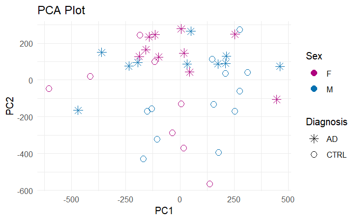

```r
# Let's explore the high dimensional methylomes in a principle component analysis
pcaRes <- prcomp(t(mmExTissue), center = TRUE, scale. = TRUE)

pcaData <- as.data.frame(pcaRes$x)
pcaData$SampleID = rownames(pcaData)
pcaData = merge(x = pcaData, y = pheno(rnbEx), by = "SampleID")

ggplot(pcaData, aes(x = PC1, y = PC2, color = Sex, shape = Diagnosis)) +
  geom_point(size = 3) +
  scale_color_manual(values = c("#ae017e", "#0570b0")) +
  scale_shape_manual(values = c(8, 1))+
  theme_minimal() +
  labs(title = "PCA Plot")
```

Investigate the most varibale probes in the cell type samples

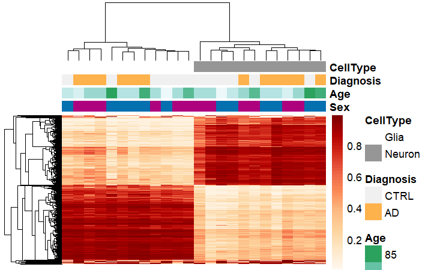

```r
mmExCell = mmEx[ , grepl("Glia|Neuron", colnames(mmEx))]
rowVars <- apply(mmExCell, 1, var)

mmMostVar = mmExCell[ order(rowVars, decreasing = T)[1:10000] , ]

anno = data.frame(pheno(rnbEx)[ , c("Sex","Age","Diagnosis","CellType")])
annoCol = list(Sex = c("M" = "#0570b0", "F" = "#ae017e"),
               Diagnosis = c("CTRL" = "#f0f0f0", "AD" = "#feb24c"),
               CellType = c("Glia" = "white","Neuron" = "#969696"))

pheatmap(mmMostVar,
         clustering_distance_rows = "euclidean",
         clustering_distance_cols = "euclidean",
         col = colors,
         annotation_col = anno,
         annotation_colors = annoCol,
         show_colnames = F,
         show_rownames = F,
         cellwidth = 10
         #cellheight = 10
)
```

### RnBeads sets

In order to save time for analysis which can take sometime hours of wait. We have already have some objects ready for you. You will have the option later on to use these objects and at the same time also create your own objects in case you have enough time at the end of each session.

```r
rnbUnp <- load.rnb.set("d:/Work/Epigenetics/Workshops/2024_deNBI-DNA_methylation_design_to_discovery/analysis/rnbSet_Unprocessed.zip")

rnbFilt <- load.rnb.set("d:/Work/Epigenetics/Workshops/2024_deNBI-DNA_methylation_design_to_discovery/analysis/rnbSet_Filtered.zip")

rnbEx <- load.rnb.set("d:/Work/Epigenetics/Workshops/2024_deNBI-DNA_methylation_design_to_discovery/analysis/rnbSet_exploratoryAnalysis.zip")
```